# Dev Submission

Step 1: Installing necessary package

```r
#install.packages("Benchmarking")
library("Benchmarking")
```

Step 2: Reading input

```r
x <- matrix(c(150,400,320,520,350,320,0.2,0.7,1.2,2,1.2,0.7), ncol=2)

y <- matrix(c(14000,14000,42000,28000,19000,14000,3500,21000,10500,42000,25000,15000), ncol=2)

colnames(x) <- c("staff Hours Per Day","Supplies Per Day")

colnames(y) <- c("Reimbursed Patient Days","Privately Paid Patient Days")

x
```

```
##      staff Hours Per Day Supplies Per Day
## [1,]                 150              0.2
## [2,]                 400              0.7
## [3,]                 320              1.2
## [4,]                 520              2.0
## [5,]                 350              1.2
## [6,]                 320              0.7
```

```r
y
```

```
##      Reimbursed Patient Days Privately Paid Patient Days
## [1,]                   14000                        3500
## [2,]                   14000                       21000
## [3,]                   42000                       10500
## [4,]                   28000                       42000
## [5,]                   19000                       25000
## [6,]                   14000                       15000
```

Step 3: Running DEA Analysis for FDH

```r
fdh <- dea(x,y,RTS="fdh")

peers(fdh)
```

```
##      peer1
## [1,]     1
## [2,]     2
## [3,]     3
## [4,]     4
## [5,]     5
## [6,]     6
```

```r
lambda(fdh)
```

```
##      L1 L2 L3 L4 L5 L6
## [1,]  1  0  0  0  0  0
## [2,]  0  1  0  0  0  0
## [3,]  0  0  1  0  0  0
## [4,]  0  0  0  1  0  0
## [5,]  0  0  0  0  1  0
## [6,]  0  0  0  0  0  1
```

```r
dea.plot.isoquant(x,y,RTS="fdh")
```

[output not shown]

```r
summary(fdh)
```

```
## Summary of efficiencies
## FDH technology and input orientated efficiency
## Number of firms with efficiency==1 are 6 out of 6
## Mean efficiency: 1
## ---
##   Eff range      #   %
##         E ==1    6 100
##    Min. 1st Qu.  Median    Mean 3rd Qu.    Max.
##       1       1       1       1       1       1
```

Step 4: Running DEA Analysis for CRS

```r
crs <- dea(x,y,RTS = "crs")

peers(crs)
```

```
##      peer1 peer2 peer3
## [1,]     1    NA    NA
## [2,]     2    NA    NA
## [3,]     3    NA    NA
## [4,]     4    NA    NA
## [5,]     1     2     4
## [6,]     1     2     4
```

```r
lambda(crs)
```

```
##             L1         L2 L3        L4
## [1,] 1.0000000 0.00000000  0 0.0000000
## [2,] 0.0000000 1.00000000  0 0.0000000
## [3,] 0.0000000 0.00000000  1 0.0000000
## [4,] 0.0000000 0.00000000  0 1.0000000
## [5,] 0.2000000 0.08048142  0 0.5383307
## [6,] 0.3428571 0.39499264  0 0.1310751
```

```r
dea.plot.isoquant(x,y,RTS="crs")
```

[output not shown]

```r
summary(crs)
```

```
## Summary of efficiencies
## CRS technology and input orientated efficiency
## Number of firms with efficiency==1 are 4 out of 6
## Mean efficiency: 0.974
## ---
##   Eff range      #  %
##   0.8<= E <0.9   1 17
##   0.9<= E <1     1 17
##         E ==1    4 67
##    Min. 1st Qu.  Median    Mean 3rd Qu.    Max.
##  0.8675  0.9831  1.0000  0.9742  1.0000  1.0000
```

Step 5: Running DEA Analysis for VRS

```r
vrs <- dea(x,y,RTS = "vrs")

peers(vrs)
```

```
##      peer1 peer2 peer3
## [1,]     1    NA    NA
## [2,]     2    NA    NA
## [3,]     3    NA    NA
## [4,]     4    NA    NA
## [5,]     5    NA    NA
## [6,]     1     2     5
```

```r
lambda(vrs)
```

```
##             L1        L2 L3 L4        L5
## [1,] 1.0000000 0.0000000  0  0 0.0000000
## [2,] 0.0000000 1.0000000  0  0 0.0000000
## [3,] 0.0000000 0.0000000  1  0 0.0000000
## [4,] 0.0000000 0.0000000  0  1 0.0000000
## [5,] 0.0000000 0.0000000  0  0 1.0000000
## [6,] 0.4014399 0.3422606  0  0 0.2562995
```

```r
dea.plot.isoquant(x,y,RTS="vrs")
```

[output not shown]

```r
summary(vrs)
```

```
## Summary of efficiencies
## VRS technology and input orientated efficiency
## Number of firms with efficiency==1 are 5 out of 6
## Mean efficiency: 0.983
## ---
##   Eff range      #  %
##   0.8<= E <0.9   1 17
##   0.9<= E <1     0  0
##         E ==1    5 83
##    Min. 1st Qu.  Median    Mean 3rd Qu.    Max.
##  0.8963  1.0000  1.0000  0.9827  1.0000  1.0000
```

Step 6: Running DEA Analysis for IRS

```r
irs <- dea(x,y,RTS = "irs")

peers(irs)
```

```
##      peer1 peer2 peer3
## [1,]     1    NA    NA
## [2,]     2    NA    NA
## [3,]     3    NA    NA
## [4,]     4    NA    NA
## [5,]     5    NA    NA
## [6,]     1     2     5
```

```r
lambda(irs)
```

```
##             L1        L2 L3 L4        L5
## [1,] 1.0000000 0.0000000  0  0 0.0000000
## [2,] 0.0000000 1.0000000  0  0 0.0000000
## [3,] 0.0000000 0.0000000  1  0 0.0000000
## [4,] 0.0000000 0.0000000  0  1 0.0000000
## [5,] 0.0000000 0.0000000  0  0 1.0000000
## [6,] 0.4014399 0.3422606  0  0 0.2562995
```

```r
dea.plot.isoquant(x,y,RTS="irs")
```

[output not shown]

```r
summary(irs)
```

```
## Summary of efficiencies
## IRS technology and input orientated efficiency
## Number of firms with efficiency==1 are 5 out of 6
## Mean efficiency: 0.983
## ---
##   Eff range      #  %
##   0.8<= E <0.9   1 17
##   0.9<= E <1     0  0
##         E ==1    5 83
##    Min. 1st Qu.  Median    Mean 3rd Qu.    Max.
##  0.8963  1.0000  1.0000  0.9827  1.0000  1.0000
```

Step 7: Running DEA Analysis for DRS

```r
drs <- dea(x,y,RTS = "drs")

peers(drs)
```

```
##      peer1 peer2 peer3
## [1,]     1    NA    NA
## [2,]     2    NA    NA
## [3,]     3    NA    NA
## [4,]     4    NA    NA
## [5,]     1     2     4
## [6,]     1     2     4
```

```r
lambda(drs)
```

```
##             L1         L2 L3        L4
## [1,] 1.0000000 0.00000000  0 0.0000000
## [2,] 0.0000000 1.00000000  0 0.0000000
## [3,] 0.0000000 0.00000000  1 0.0000000
## [4,] 0.0000000 0.00000000  0 1.0000000
## [5,] 0.2000000 0.08048142  0 0.5383307
## [6,] 0.3428571 0.39499264  0 0.1310751
```

```r
dea.plot.isoquant(x,y,RTS="drs")
```

[output not shown]

```r
summary(drs)
```

```
## Summary of efficiencies
## DRS technology and input orientated efficiency
## Number of firms with efficiency==1 are 4 out of 6
## Mean efficiency: 0.974
## ---
##   Eff range      #  %
##   0.8<= E <0.9   1 17
##   0.9<= E <1     1 17
##         E ==1    4 67
##    Min. 1st Qu.  Median    Mean 3rd Qu.    Max.
##  0.8675  0.9831  1.0000  0.9742  1.0000  1.0000
```

Step 7: Running DEA Analysis for FDH+

```r
fdh_plus <- dea(x,y,RTS="fdh+")

peers(fdh_plus)
```

```
##      peer1
## [1,]     1
## [2,]     2
## [3,]     3
## [4,]     4
## [5,]     5
## [6,]     6
```

```r
lambda(fdh_plus)
```

```
##      L1 L2 L3 L4 L5 L6
## [1,]  1  0  0  0  0  0
## [2,]  0  1  0  0  0  0
## [3,]  0  0  1  0  0  0
## [4,]  0  0  0  1  0  0
## [5,]  0  0  0  0  1  0
## [6,]  0  0  0  0  0  1
```

```r
summary(fdh_plus)
```

```
## Summary of efficiencies
## FDH+ technology and input orientated efficiency
## Number of firms with efficiency==1 are 6 out of 6
## Mean efficiency: 1
## ---
##   Eff range      #   %
##         E ==1    6 100
##    Min. 1st Qu.  Median    Mean 3rd Qu.    Max.
##       1       1       1       1       1       1
```

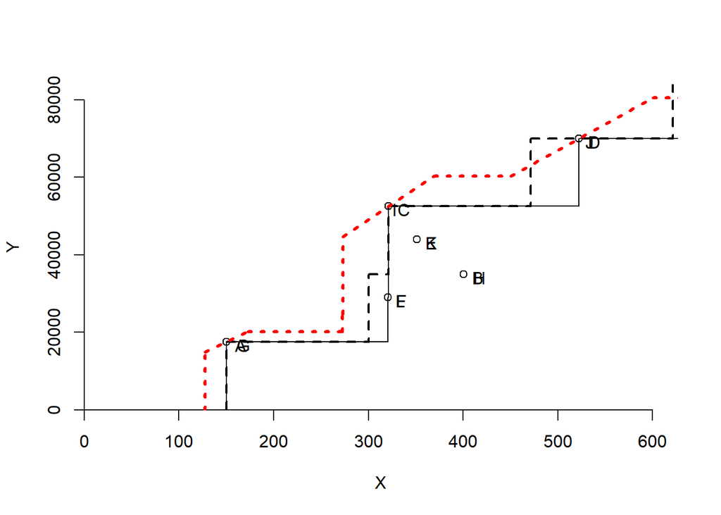

```r
dea.plot(x,y,RTS="fdh",ORIENTATION="in-out",txt=LETTERS[1:length(x)])
dea.plot(x,y,RTS="add",ORIENTATION="in-out",add=TRUE,lty="dashed",lwd=2)
dea.plot(x,y,RTS="fdh+",ORIENTATION="in-out",add=TRUE,lty="dotted",lwd=3,col="red")
```

Step 8: Compare & Contrast

FDH technology and input orientated efficiency Number of firms with efficiency==1 are 6 out of 6 Mean efficiency: 1 —  
Eff range # % E ==1 6 100

VRS technology and input orientated efficiency Number of firms with efficiency==1 are 5 out of 6 Mean efficiency: 0.983 —  
Eff range # % 0.8<= E <0.9 1 17 0.9<= E <1 0 0 E ==1 5 83

DRS technology and input orientated efficiency Number of firms with efficiency==1 are 4 out of 6 Mean efficiency: 0.974 —  
Eff range # % 0.8<= E <0.9 1 17 0.9<= E <1 1 17 E ==1 4 67

CRS technology and input orientated efficiency Number of firms with efficiency==1 are 4 out of 6 Mean efficiency: 0.974 —  
Eff range # % 0.8<= E <0.9 1 17 0.9<= E <1 1 17 E ==1 4 67 _

IRS technology and input orientated efficiency Number of firms with efficiency==1 are 5 out of 6 Mean efficiency: 0.983 —  
Eff range # % 0.8<= E <0.9 1 17 0.9<= E <1 0 0 E ==1 5 83 _

FDH+ technology and input orientated efficiency Number of firms with efficiency==1 are 6 out of 6 Mean efficiency: 1 —  
Eff range # % E ==1 6 100